# SWNS/BoF Herring MSE MP Testing Draft Results GM MPs

2021-10-18

# Summary of Results

## Updates

Updates Since Version 1 (May 19, 2021):

Primary Updates:

- The data inputs have been updated to include data up to 2020. These data are summarized [here](https://drive.google.com/drive/folders/1gYkdtqjz4TnkWBp9CrF-ktn3eRZigoii?usp=sharing).
- MPs submitted by the group have been included. Some other example MPs from Version 1 are also included.
- The acoustic index in the projections is now assumed to be proportional to SSB. In Version 1, a hyperstability parameter was estimated from the historical data (observed acoustic index and model estimated SSB) that was less than 1 for most simulations. This hyperstability parameter was used to estimate the acoustic index in the projections in Version 1.
- A new table was added showing the probability of the 3-yr moving average acoustic index being above the limit reference point of 318 kt in each of the first 15 years of the projections.

Minor Updates:

- All performance metrics using the acoustic index are now based on the 3-yr moving average acoustic index.
- The “average” performance is now is based on the median across all simulation and not the mean.
- Trade-off plots now show the average performance of the most pessimistic, optimistic, and median OMs (instead of the 10<sup>th</sup>, 90<sup>th</sup>, and median across all simulations pooled across all OMs).
- The results for the Robustness OMs have not been added yet.

## Objectives

DRAFT

MSE Objectives

- Maintain SSB above the minimum performance threshold
- Maintain SSB above a target biomass in the long term
- Maximize yield
- Minimize variability in catch
- Limit the removal of small fish

MP selection will also consider performance relative to the limit reference point in terms of the 3-yr moving average acoustic index

## Performance Metrics

DRAFT

Performance Threshold

Threshold = 0.7SSB<sub>MSY</sub> (dynamic)

- P(SSB>0.7SSB<sub>MSY</sub>) > 75% in each year beginning in year 10 of the 25-year projection period

*The performance threshold is used to eliminate MPs from further consideration*

Performance Metrics

| Objective | Metric | Timeframe |
| --- | --- | --- |
| Maintain SSB above a target biomass in the long term | P(SSB > SSBmsy) | Years 16-25 |
| Maximize short term yield | Average Yield | Years 1-5 |
| Maximize long term yield | Average Yield | Years 6-25 |
| Minimize variability in catch | Average inter-annual variability in yield | Years 1-25 |
| Limit the removal of small fish | % Small Fish (<23 cm) | Years 1-15 |

*These performance metrics are used to rank the performance of MPs and are not used to eliminate MPs from consideration. Note that SSB<sub>MSY</sub> represents a potential target used for ranking the performance of MPs.*

The following additional performance metrics are presented:

- P(SSB > SSB<sub>2007</sub>) and # years to reach this value in the projections
- P(3-yr Moving Average Acoustic Index > 318 kt) and # years to reach this value in the projections
- P(SSB > 0.7SSB<sub>MSY</sub>_static1990-2020) and # years to reach this value in the projections
- P(SSB > 0.3SSB<sub>0</sub>_static1990-2020) and # years to reach this value in the projections

Other performance metrics (for ranking MPs) can be added upon request

## OMs

### Reference Set

DRAFT

4 Principal Axes of Uncertainty:

- Natural Mortality Rate:
  - M = 0.35
  - M = 0.49 (Age 1-2) and 0.26 (Age 3+)
  - M = 0.79 (Age 1-2) and 0.45 (Age 3+)
- Future Growth:
  - status quo: mean of last 3 years
  - change: extrapolation of regression of weight at age vs. year
- Steepness:
  - h = 0.95
  - h = 0.65
- Weir catch and size composition data:
  - exclude = exclude weir fleet
  - include = include weir fleet

| OM | M | Growth | h | Weir |
| --- | --- | --- | --- | --- |
| 1 | 0.35 | status quo | 0.95 | exclude |
| 2 | 0.49 (Age 1-2), 0.26 (Age 3+) | status quo | 0.95 | exclude |
| 3 | 0.79 (Age 1-2), 0.45 (Age 3+) | status quo | 0.95 | exclude |
| 4 | 0.35 | change | 0.95 | exclude |
| 5 | 0.49 (Age 1-2), 0.26 (Age 3+) | change | 0.95 | exclude |
| 6 | 0.79 (Age 1-2), 0.45 (Age 3+) | change | 0.95 | exclude |
| 7 | 0.35 | status quo | 0.65 | exclude |
| 8 | 0.49 (Age 1-2), 0.26 (Age 3+) | status quo | 0.65 | exclude |
| 9 | 0.79 (Age 1-2), 0.45 (Age 3+) | status quo | 0.65 | exclude |
| 10 | 0.35 | change | 0.65 | exclude |
| 11 | 0.49 (Age 1-2), 0.26 (Age 3+) | change | 0.65 | exclude |
| 12 | 0.79 (Age 1-2), 0.45 (Age 3+) | change | 0.65 | exclude |
| 13 | 0.35 | status quo | 0.95 | include |
| 14 | 0.49 (Age 1-2), 0.26 (Age 3+) | status quo | 0.95 | include |
| 15 | 0.79 (Age 1-2), 0.45 (Age 3+) | status quo | 0.95 | include |
| 16 | 0.35 | change | 0.95 | include |
| 17 | 0.49 (Age 1-2), 0.26 (Age 3+) | change | 0.95 | include |
| 18 | 0.79 (Age 1-2), 0.45 (Age 3+) | change | 0.95 | include |
| 19 | 0.35 | status quo | 0.65 | include |
| 20 | 0.49 (Age 1-2), 0.26 (Age 3+) | status quo | 0.65 | include |
| 21 | 0.79 (Age 1-2), 0.45 (Age 3+) | status quo | 0.65 | include |
| 22 | 0.35 | change | 0.65 | include |
| 23 | 0.49 (Age 1-2), 0.26 (Age 3+) | change | 0.65 | include |
| 24 | 0.79 (Age 1-2), 0.45 (Age 3+) | change | 0.65 | include |

### Robustness Set

#### Rob Set 1

DRAFT

*Note: 6 robustness OMs have been submitted by the herring MSE group. Additional robustness OMs can be added upon request*

Additional levels for:

*Note: Assumed selectivity for the US catches is the purse seine fleet selectivity.*

| OM | M | Growth | h | Weir | Recruitment | Additional Catch |
| --- | --- | --- | --- | --- | --- | --- |
| ROB1 | 0.35 | 1% increase | 0.95 | include | 90-15 | none |
| ROB2 | 0.35 | backstep | 0.95 | include | 90-15 | none |
| ROB3 | 0.35 | status quo | 0.95 | include | 68-15 | none |
| ROB4 | 0.35 | status quo | 0.95 | include | 90% | none |
| ROB5 | 0.35 | status quo | 0.95 | include | 90-15 | US Fish |
| ROB6 | 0.35 | status quo | 0.95 | include | 90-15 | High Weir |

## MPs

### Description

DRAFT

| MP | Description |
| --- | --- |
| NFref | F=0 Reference |
| SQ | NA |
| MP_GM_01 | submitted by group |
| MP_GM_02 | submitted by group |

Status Quo MP: an approximation of the status quo MP

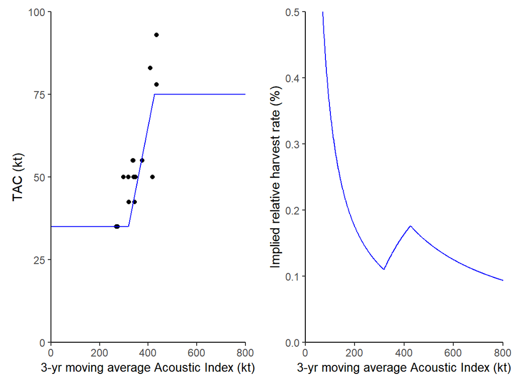

SQ Modifications

Change minimum TAC to lower harvest rate below the minimum operational control point.

Example MP of form “MP _ TAC1 _ TAC2 _ Index1 _ Index2 _ X Year”

These MPs are modifications of the status quo MP by changing the position of the operational control points and the smoothing of the acoustic index:

- TAC1 = lower control point for the TAC
- TAC2 = upper control point for the TAC
- Index1 = lower control point for the acoustic index
- Index2 = upper control point for the acoustic index
- X Year = number of years used in the moving average smoother for the acoustic index

Example “MP_20_60_318_425_3”

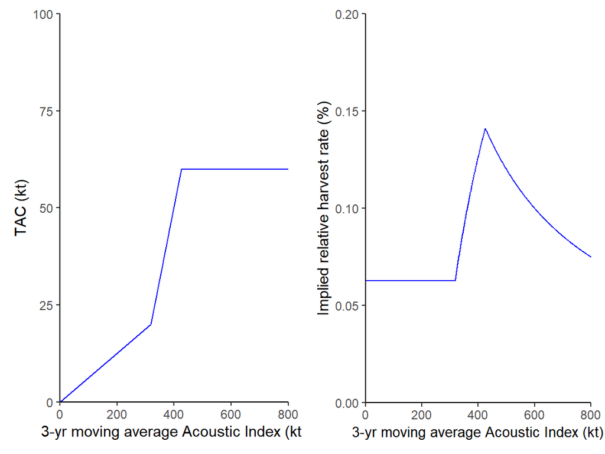

MPs submitted by group:

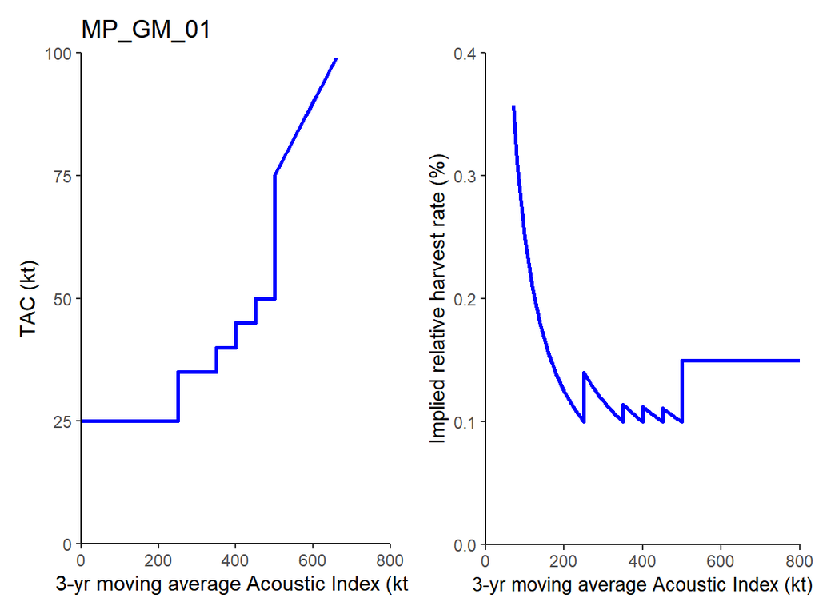

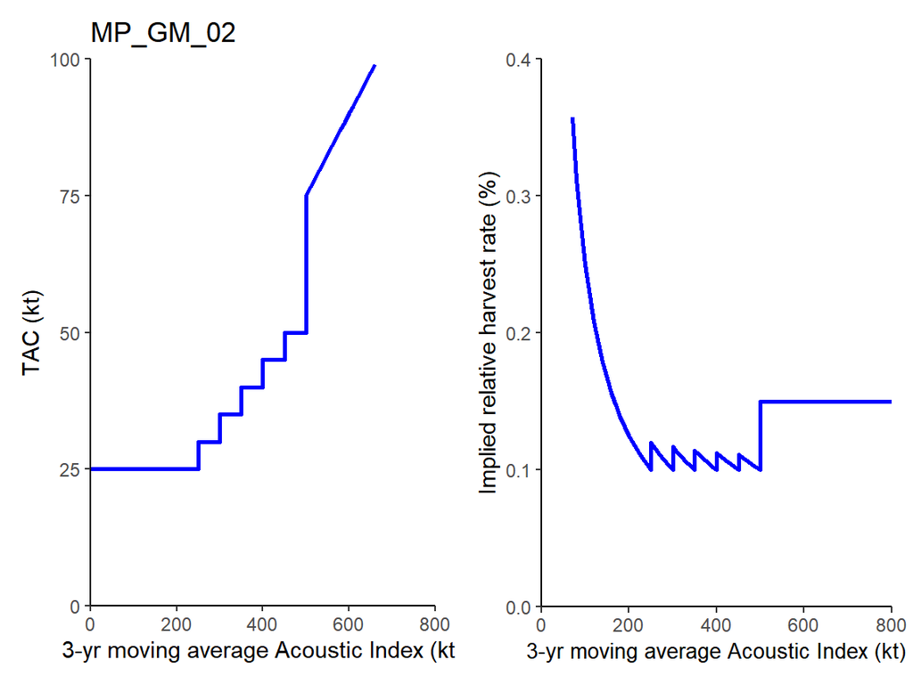

## MP Testing

### Pass/Fail Performance

DRAFT

Performance Threshold: P(SSB > 0.7SSB<sub>MSY</sub>) > 75% in each year beginning in year 10 of the 25-year projection period

| Pass | Fail |
| --- | --- |
| NFref | MP_GM_01 |
|  | MP_GM_02 |
|  | SQ |

### Projection Plots

#### SSB/SSB<sub>MSY</sub>

##### Passing MPs

DRAFT

Thick black line = median across all simulations

Grey shading = 10<sup>th</sup>, 25<sup>th</sup>, 75<sup>th</sup>, and 90<sup>th</sup> percentiles across all simulations

Blue Line = median dynamic SSB<sub>0</sub> / SSB<sub>MSY</sub>

Black Dashed Line = SSB<sub>MSY</sub>

Red Line = 0.7SSB<sub>MSY</sub>

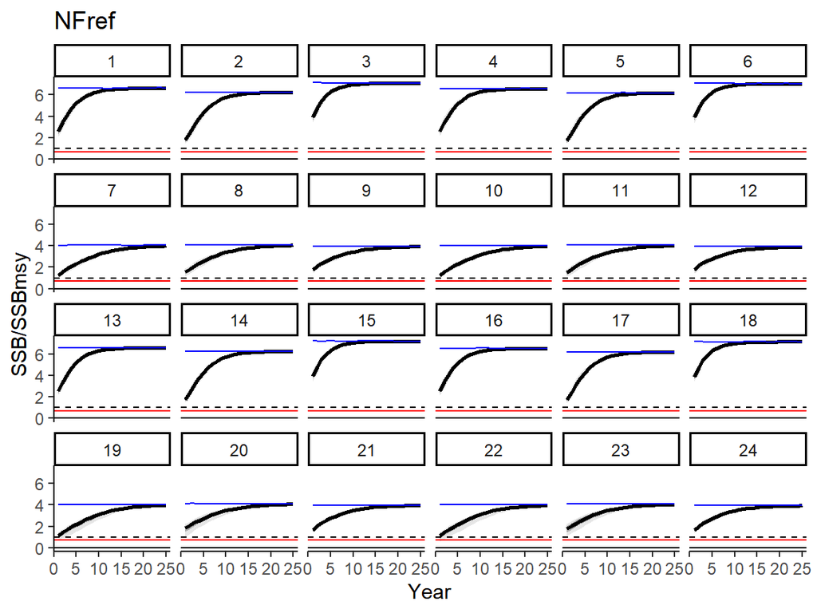

##### Failing MPs

DRAFT

Thick black line = median across all simulations

Grey shading = 10<sup>th</sup>, 25<sup>th</sup>, 75<sup>th</sup>, and 90<sup>th</sup> percentiles across all simulations

Blue Line = median dynamic SSB<sub>0</sub> / SSB<sub>MSY</sub>

Black Dashed Line = SSB<sub>MSY</sub>

Red Line = 0.7SSB<sub>MSY</sub>

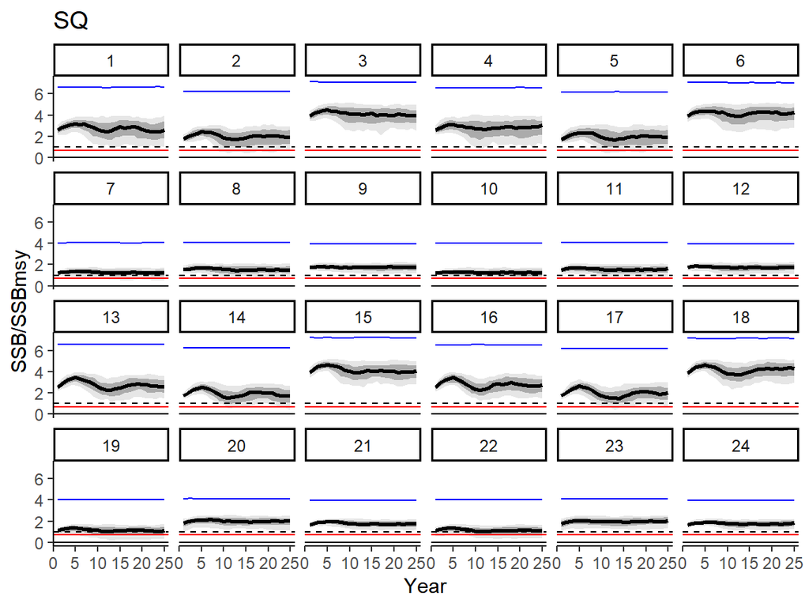

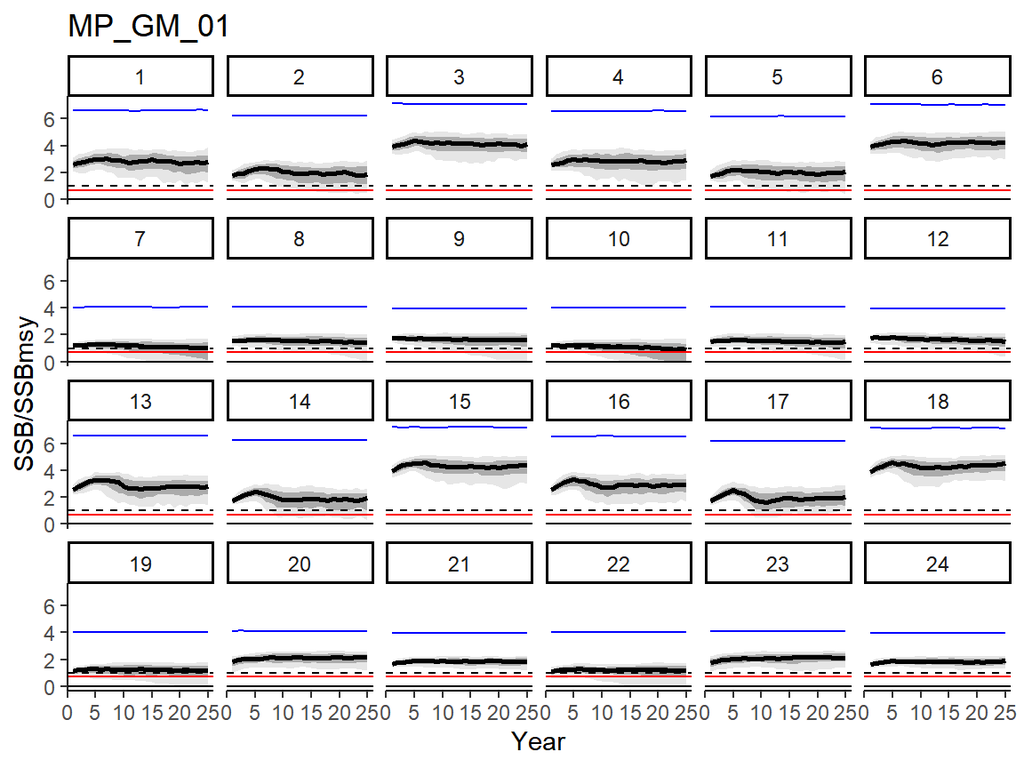

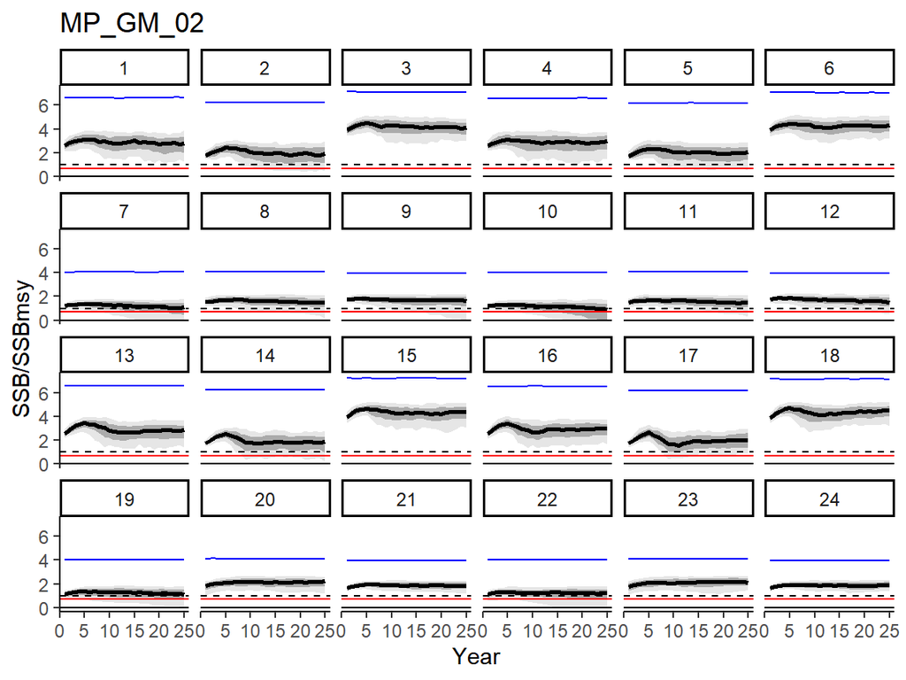

#### SSB

##### Passing MPs

DRAFT

Thick black line = median across all simulations

Grey shading = 10<sup>th</sup>, 25<sup>th</sup>, 75<sup>th</sup>, and 90<sup>th</sup> percentiles across all simulations

Blue Line = median dynamic SSB<sub>0</sub>

Red Line = median dynamic 0.7SSB<sub>MSY</sub>

Red Dashed Line = SSB<sub>2007</sub>

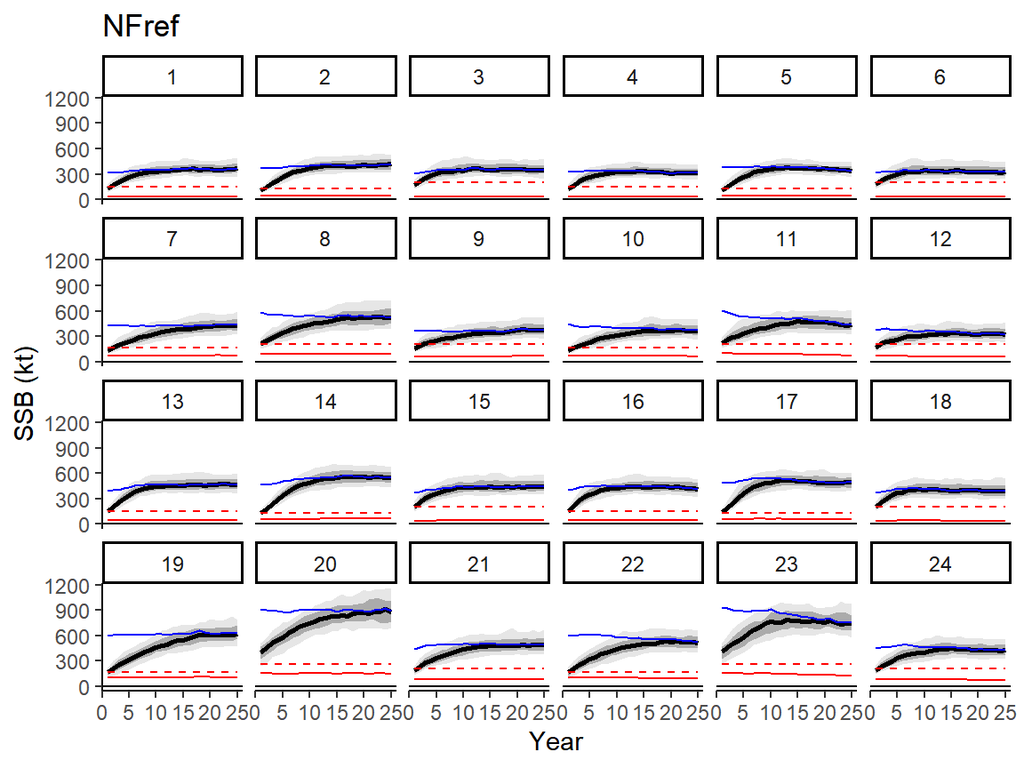

##### Failing MPs

DRAFT

Thick black line = median across all simulations

Grey shading = 10<sup>th</sup>, 25<sup>th</sup>, 75<sup>th</sup>, and 90<sup>th</sup> percentiles across all simulations

Blue Line = median dynamic SSB<sub>0</sub>

Red Line = median dynamic 0.7SSB<sub>MSY</sub>

Red Dashed Line = SSB<sub>2007</sub>

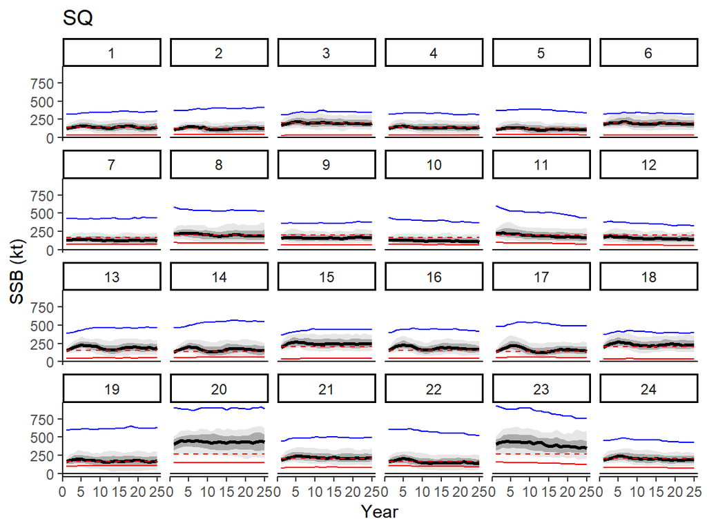

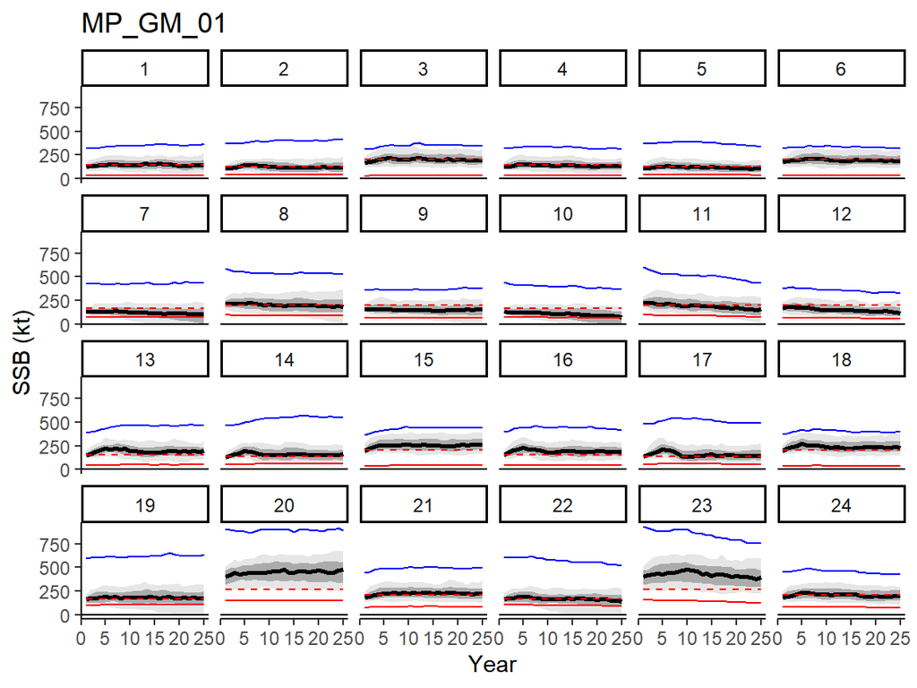

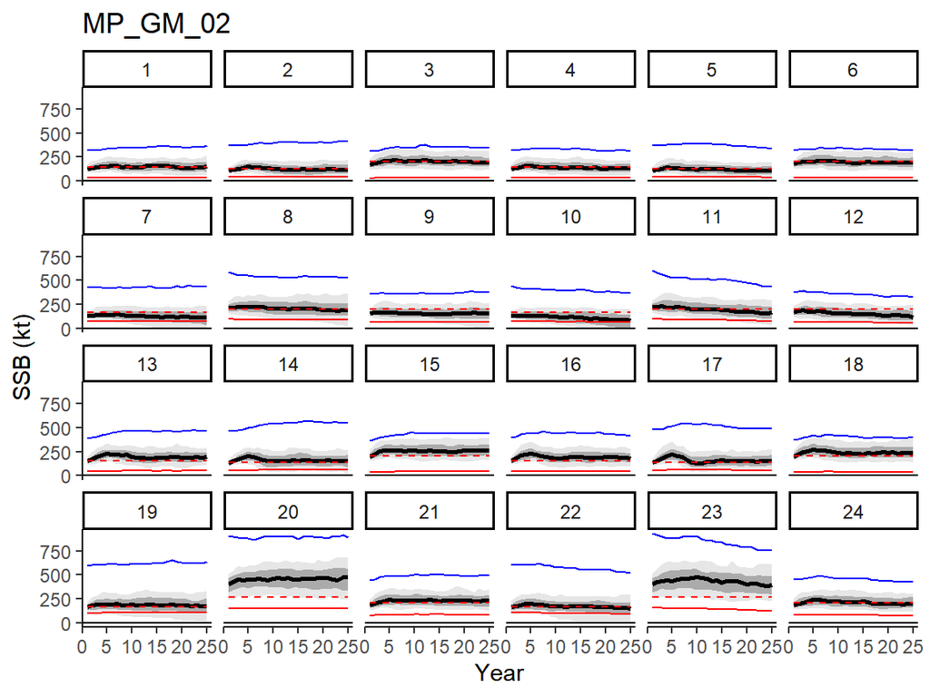

#### Acoustic Index

##### Passing MPs

DRAFT

Thick black line = median across all simulations

Grey shading = 10<sup>th</sup>, 25<sup>th</sup>, 75<sup>th</sup>, and 90<sup>th</sup> percentiles across all simulations

Blue Line = Acoustic Index (Unfished beginning in projection year 1)

Red Line = LRP (mean of 2005-2010)

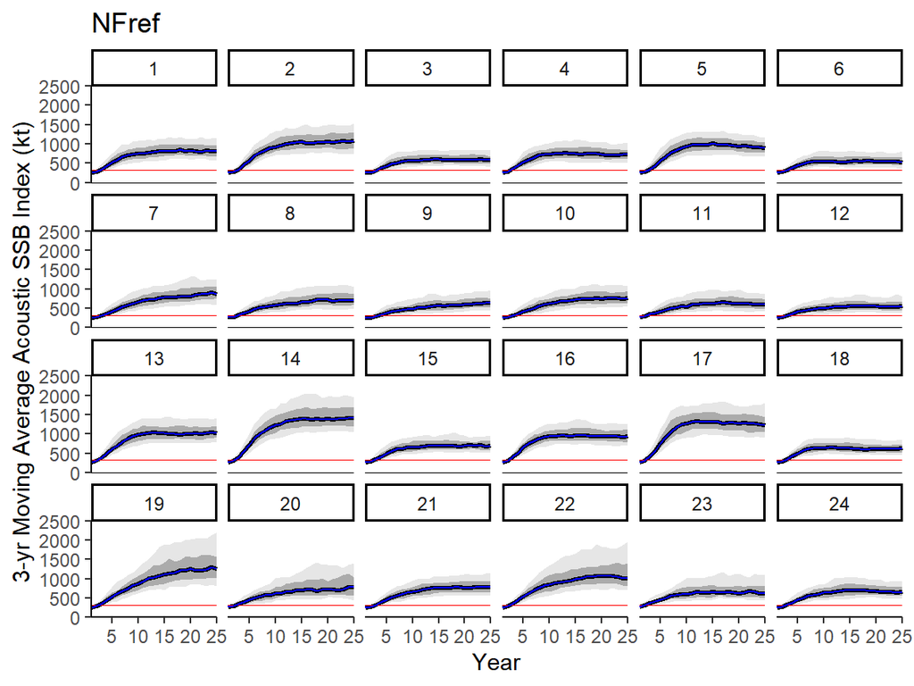

##### Failing MPs

DRAFT

Thick black line = median across all simulations

Grey shading = 10<sup>th</sup>, 25<sup>th</sup>, 75<sup>th</sup>, and 90<sup>th</sup> percentiles across all simulations

Blue Line = Acoustic Index (Unfished beginning in projection year 1)

Red Line = Exisiting LRP of mean of 2005-2010

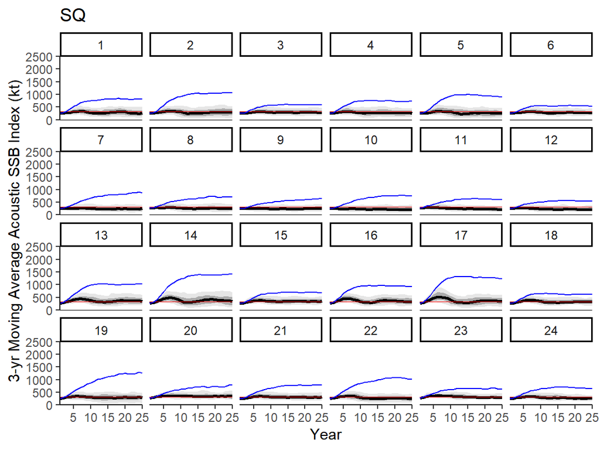

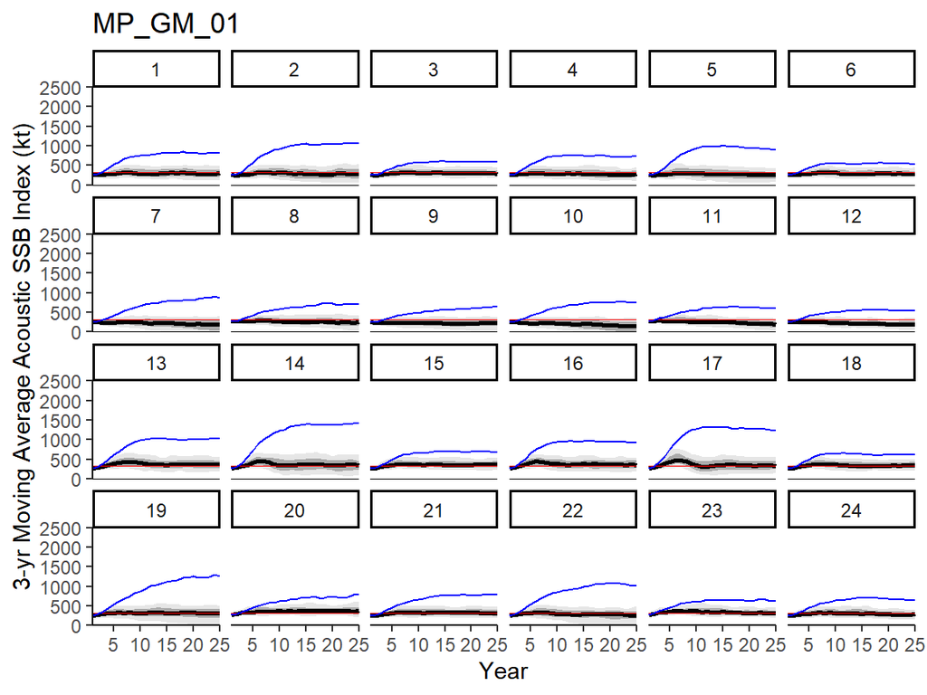

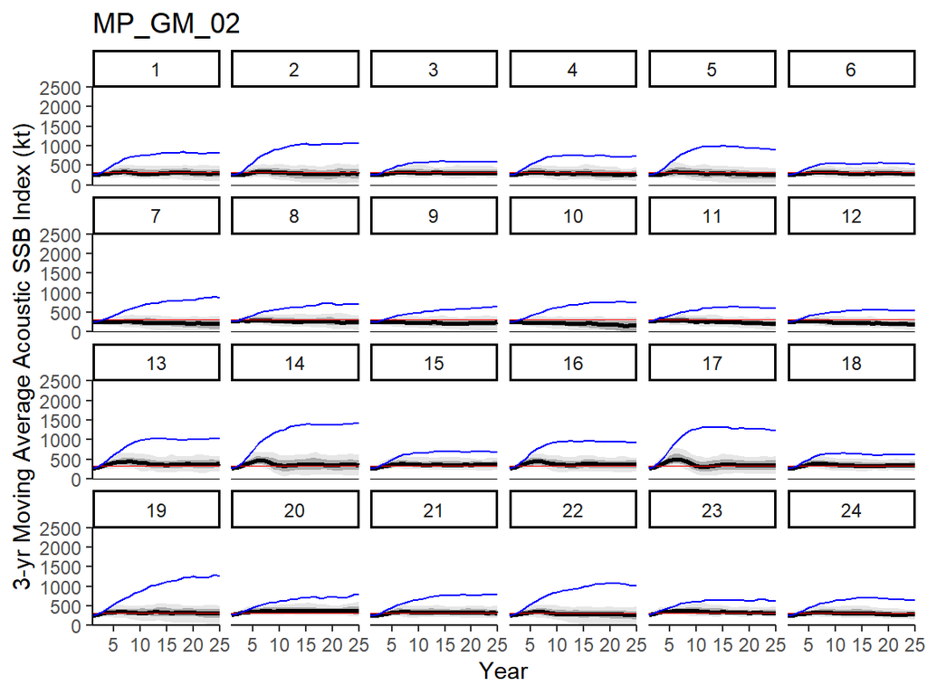

### Tradeoff Plots

DRAFT

**All MPs are displayed**

Plots show the performance for median across OMs. Error bars = performance for the most pessimistic and optimistic OMs

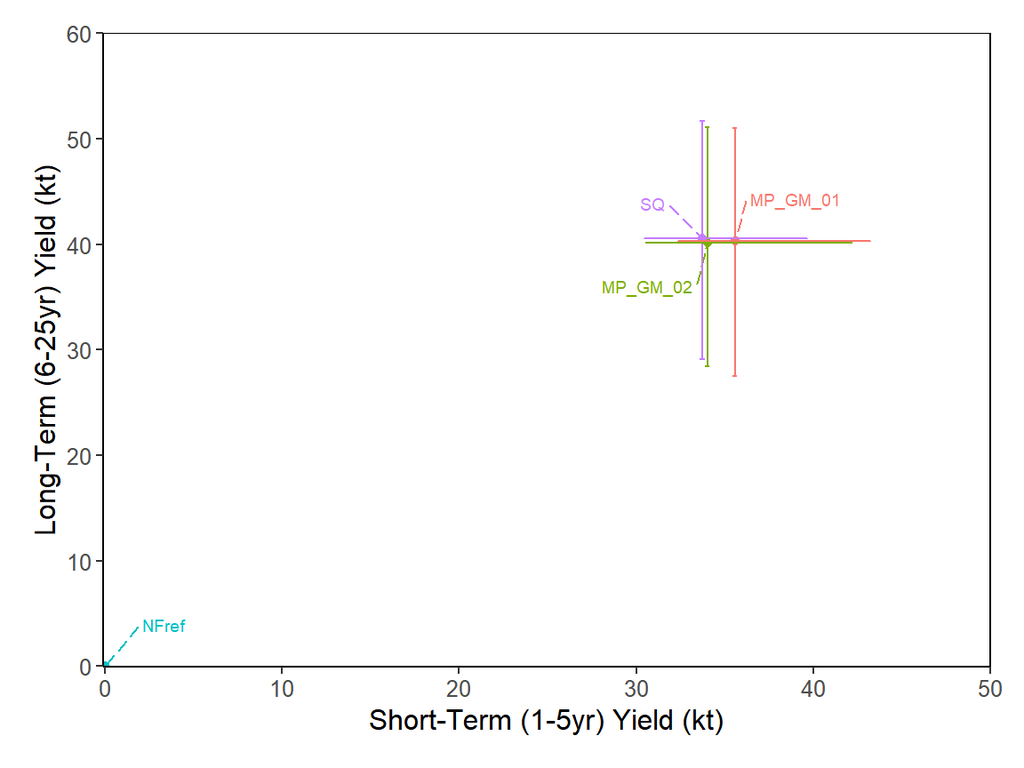

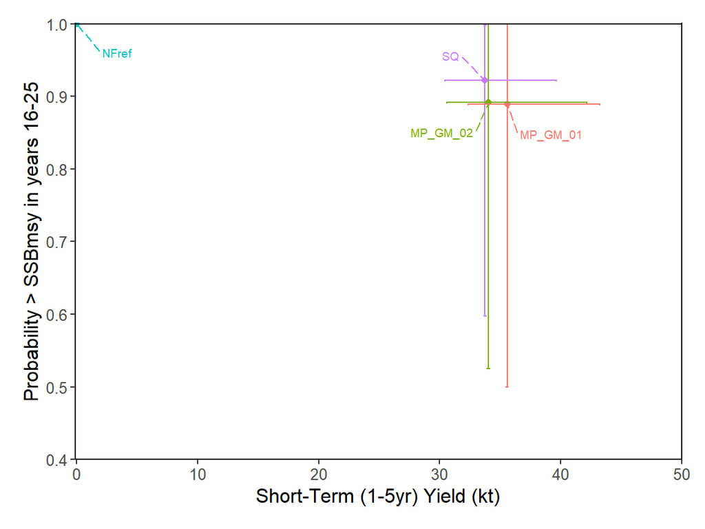

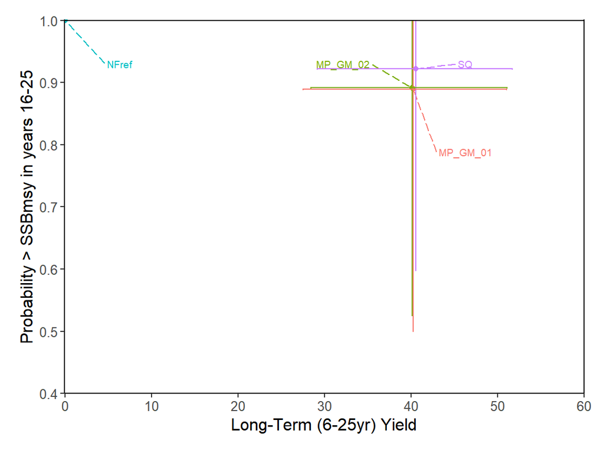

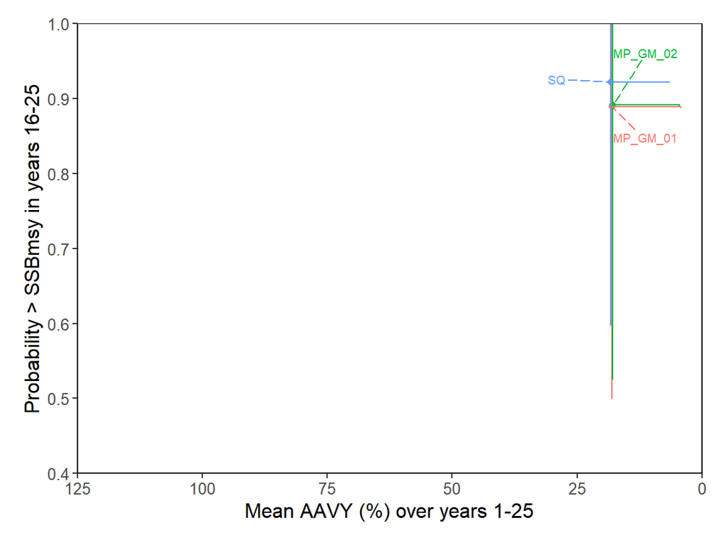

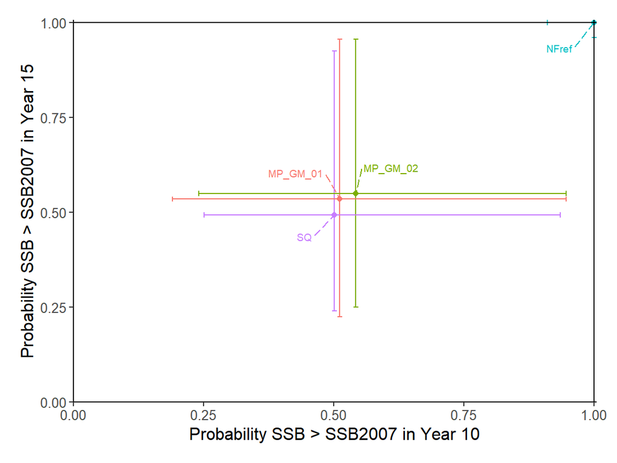

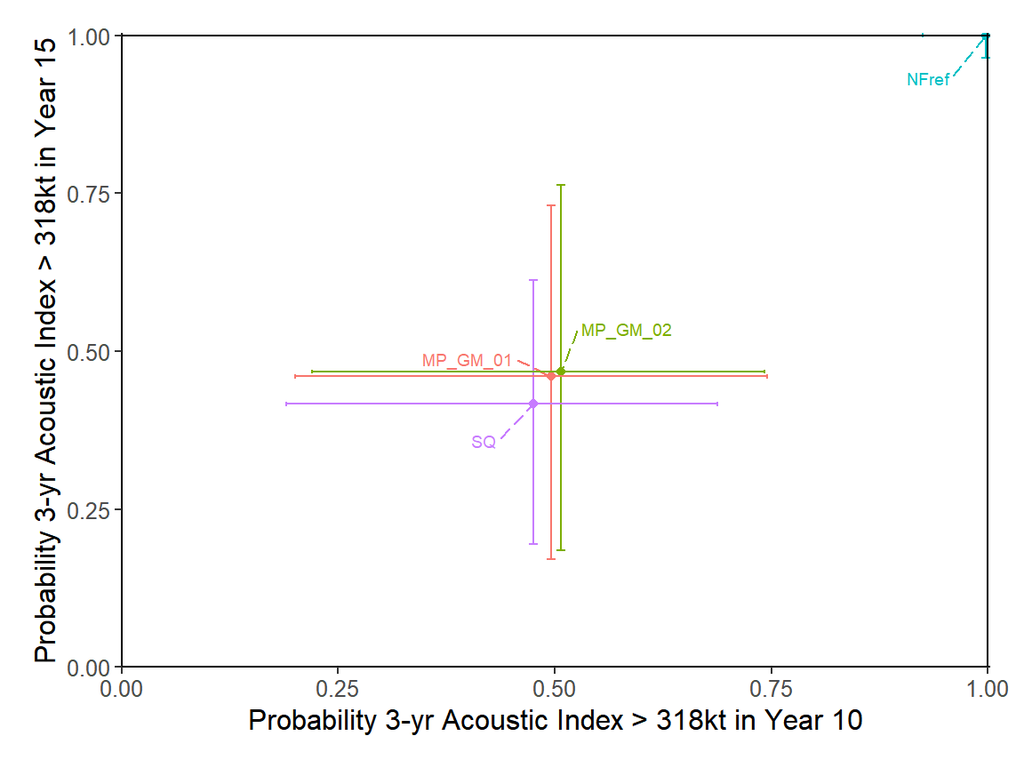

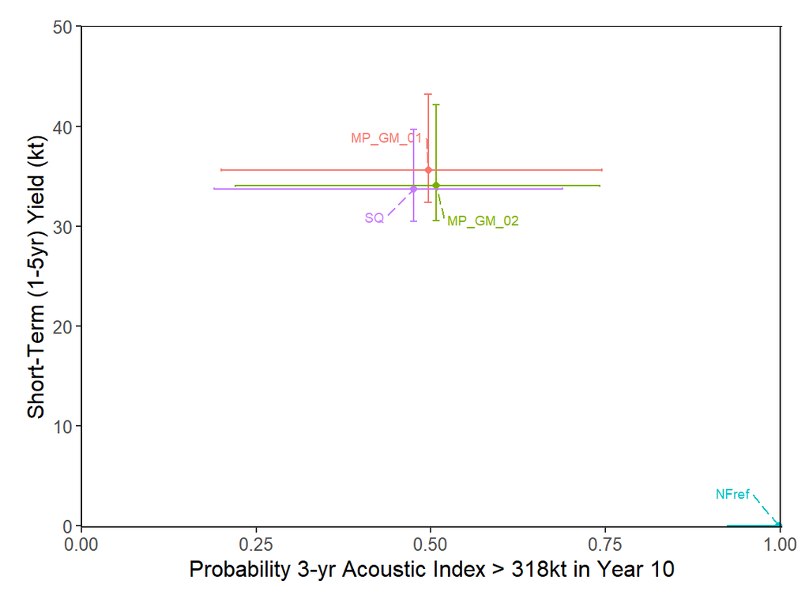

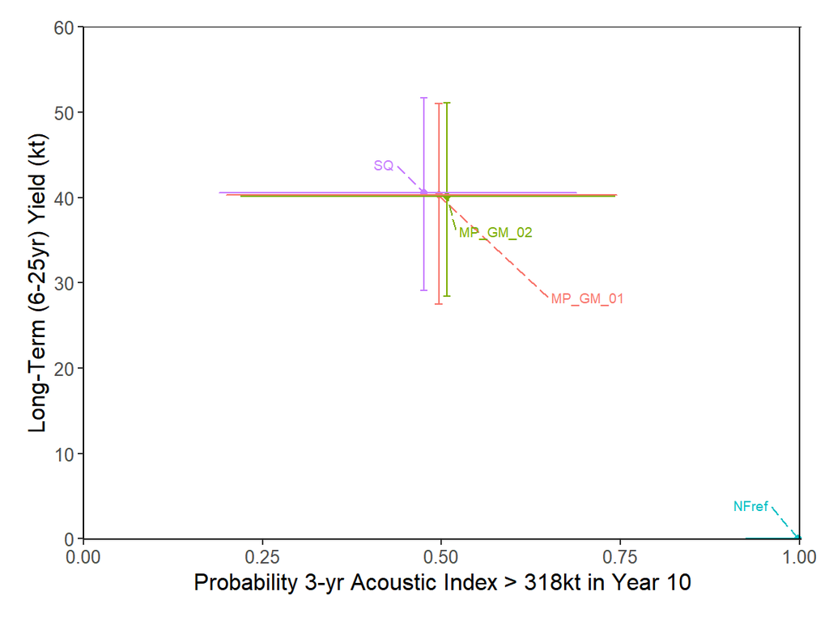

Additional Metrics to evaluate the time to reach these “benchmarks”

- SSB > SSB<sub>2007</sub>
- Acoustic Index > 318 kt
- SSB > 0.7SSB<sub>MSY</sub>_static1990-2020
- SSB > 0.3SSB<sub>0</sub>_static1990-2020

Plots show median # of years across all simulations for each OM. Error bars = 10<sup>th</sup> and 90<sup>th</sup> percentiles

Notes: y-axis is log-scaled.

Blue Lines = reference lines at 10 and 20 years

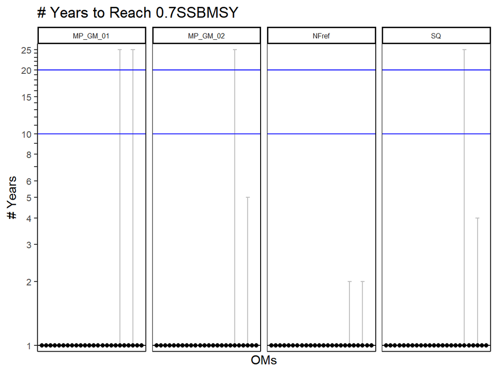

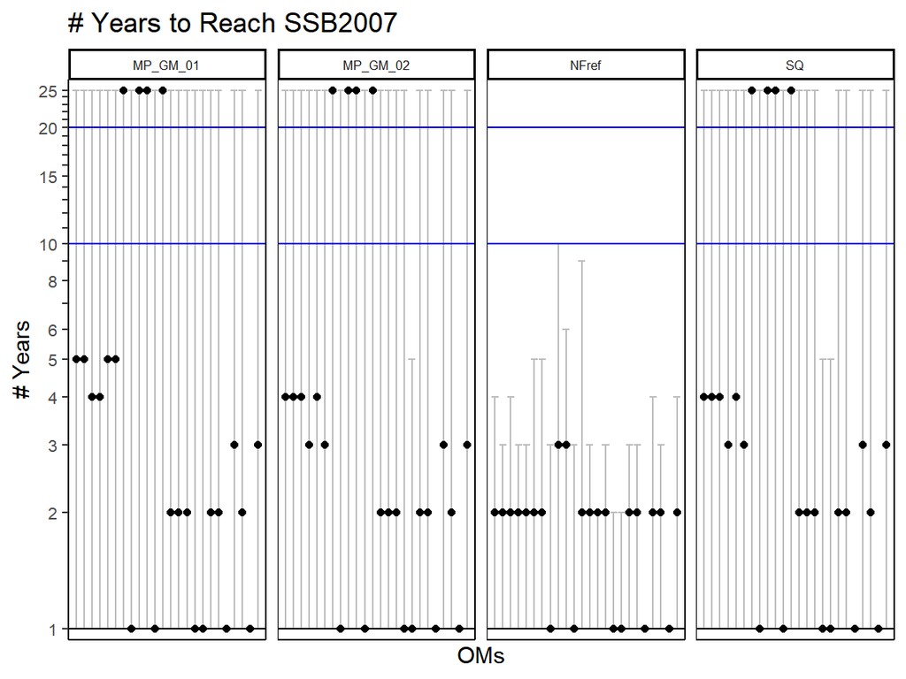

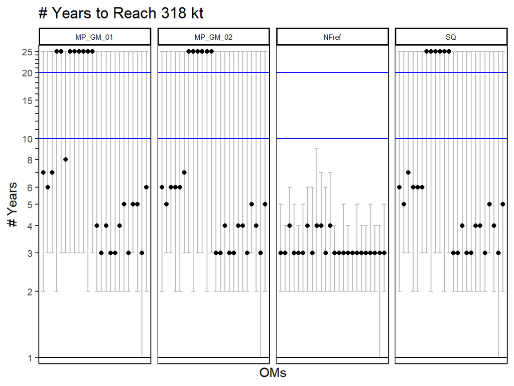

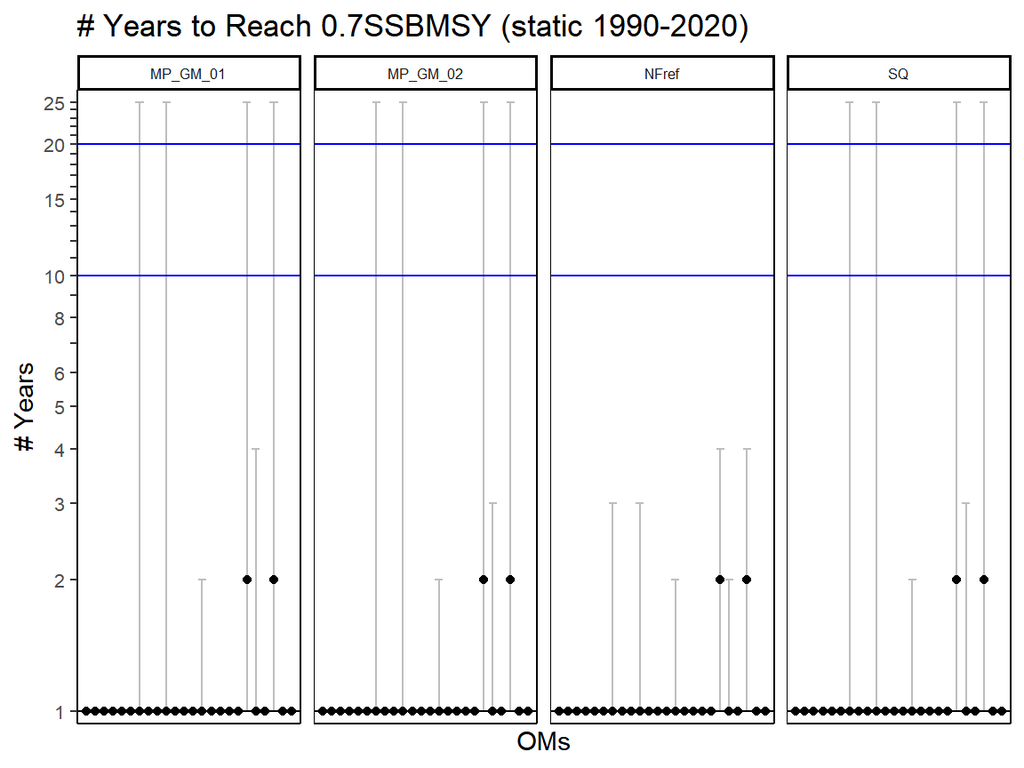

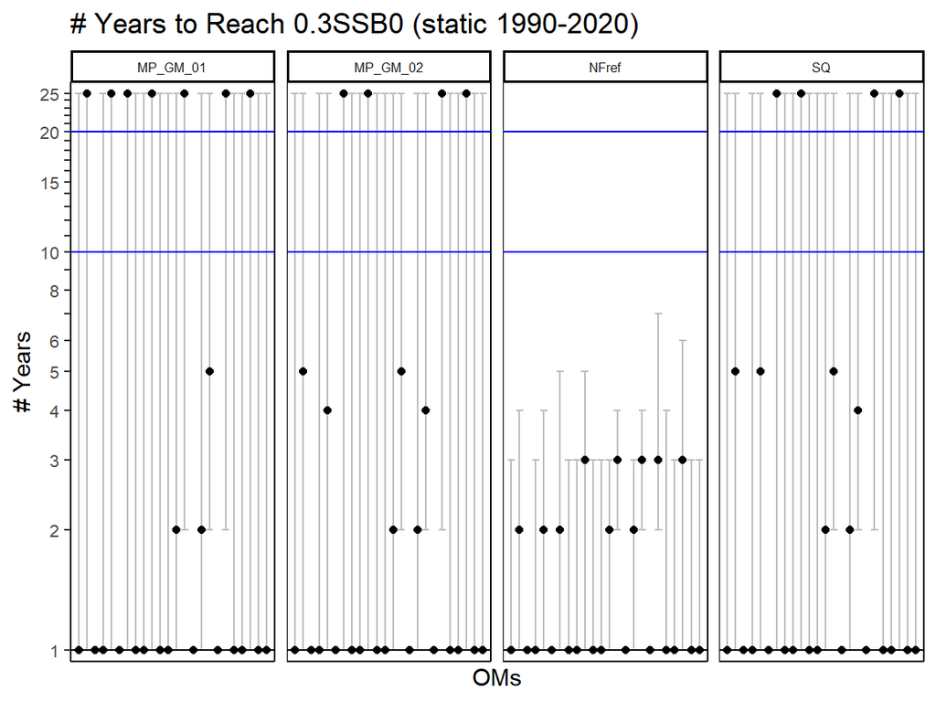

### Table of Results by MP

DRAFT

**All MPs are displayed**

STY = Short term (1-5 year) yield (kt)

LTY = Long term (6-25 year) yield (kt)

AAVY = average annual variability in yield (%)

TARG = Probability of SSB being above SSB<sub>MSY</sub> in years 16-25

SSB07 = Probability of SSB being above SSB<sub>2007</sub> in year 10

IND = Probability of the 3-yr moving average Acoustic Index being above 318 kt in year 10

|  | MP | STY_l | STY | STY_u | LTY_l | LTY | LTY_u | AAVY_l | AAVY | AAVY_u | P>Targ_l | P>Targ | P>Targ_u | P>SSB07_l | P>SSB07 | P>SSB07_u | P>318kt_l | P>318kt | P>318kt_u |
| --- | --- | --- | --- | --- | --- | --- | --- | --- | --- | --- | --- | --- | --- | --- | --- | --- | --- | --- | --- |
| 1 | MP_GM_01 | 32 | 36 | 43 | 28 | 40 | 51 | 4.3 | 18 | 18 | 0.50 | 0.89 | 1.0 | 0.19 | 0.51 | 0.95 | 0.20 | 0.50 | 0.74 |
| 2 | MP_GM_02 | 31 | 34 | 42 | 28 | 40 | 51 | 4.5 | 18 | 18 | 0.53 | 0.89 | 1.0 | 0.24 | 0.54 | 0.95 | 0.22 | 0.51 | 0.74 |
| 3 | NFref | 0 | 0 | 0 | 0 | 0 | 0 |  |  |  | 1.0 | 1.0 | 1.0 | 0.91 | 1.0 | 1.0 | 0.92 | 1.0 | 1.0 |
| 4 | SQ | 30 | 34 | 40 | 29 | 41 | 52 | 6.5 | 18 | 18 | 0.60 | 0.92 | 1.0 | 0.25 | 0.50 | 0.94 | 0.19 | 0.48 | 0.69 |

**Projections for the 3-yr moving average acoustic index over 15 years**

p*i* = probability for most pessimistic OM in year *i*

m*i* = probability for median performing OM in year *i*

o*i* = probability for most optimistic OM in year *i*

|  | MP | p1 | m1 | o1 | p2 | m2 | o2 | p3 | m3 | o3 | p4 | m4 | o4 | p5 | m5 | o5 | p6 | m6 | o6 | p7 | m7 | o7 | p8 | m8 | o8 | p9 | m9 | o9 | p10 | … |
| --- | --- | --- | --- | --- | --- | --- | --- | --- | --- | --- | --- | --- | --- | --- | --- | --- | --- | --- | --- | --- | --- | --- | --- | --- | --- | --- | --- | --- | --- | --- |
| 1 | MP_GM_01 | 0 | 0.025 | 0.183 | 0.04 | 0.12 | 0.398 | 0.14 | 0.301 | 0.656 | 0.171 | 0.38 | 0.732 | 0.196 | 0.452 | 0.803 | 0.216 | 0.51 | 0.854 | 0.225 | 0.538 | 0.874 | 0.195 | 0.53 | 0.81 | 0.175 | 0.504 | 0.775 | 0.2 | … |
| 2 | MP_GM_02 | 0 | 0.025 | 0.183 | 0.04 | 0.132 | 0.409 | 0.161 | 0.342 | 0.699 | 0.191 | 0.43 | 0.793 | 0.216 | 0.51 | 0.854 | 0.271 | 0.572 | 0.884 | 0.235 | 0.599 | 0.889 | 0.2 | 0.57 | 0.803 | 0.2 | 0.528 | 0.755 | 0.22 | … |
| 3 | NFref | 0 | 0.025 | 0.183 | 0.11 | 0.232 | 0.473 | 0.385 | 0.675 | 0.939 | 0.59 | 0.872 | 0.995 | 0.755 | 0.956 | 1 | 0.825 | 0.988 | 1 | 0.835 | 0.988 | 1 | 0.865 | 0.995 | 1 | 0.915 | 0.995 | 1 | 0.925 | … |
| 4 | SQ | 0 | 0.025 | 0.183 | 0.04 | 0.132 | 0.409 | 0.161 | 0.357 | 0.699 | 0.196 | 0.428 | 0.788 | 0.216 | 0.515 | 0.869 | 0.27 | 0.577 | 0.889 | 0.265 | 0.592 | 0.864 | 0.2 | 0.558 | 0.815 | 0.19 | 0.508 | 0.755 | 0.19 | … |

### Robustness Set Results

#### SSB/SSB<sub>MSY</sub>

DRAFT

Passing MPs

Thick black line = median across all simulations

Grey shading = 10<sup>th</sup>, 25<sup>th</sup>, 75<sup>th</sup>, and 90<sup>th</sup> percentiles across all simulations

Blue Line = median dynamic SSB<sub>0</sub> / SSB<sub>MSY</sub>

Black Dashed Line = SSB<sub>MSY</sub>

Red Line = 0.7SSB<sub>MSY</sub>

#### SSB

DRAFT

Passing MPs

Thick black line = median across all simulations

Grey shading = 10<sup>th</sup>, 25<sup>th</sup>, 75<sup>th</sup>, and 90<sup>th</sup> percentiles across all simulations

Blue Line = median dynamic SSB<sub>0</sub>

Red Line = median dynamic 0.7SSB<sub>MSY</sub>

Red Dashed Line = SSB<sub>2007</sub>

#### Acoustic Index

DRAFT

Passing MPs

Thick black line = median across all simulations

Grey shading = 10<sup>th</sup>, 25<sup>th</sup>, 75<sup>th</sup>, and 90<sup>th</sup> percentiles across all simulations

Blue Line = Acoustic Index (Unfished beginning in projection year 1)

Red Line = LRP (mean of 2005-2010 acoustic index)

## About

This report was generated on: 2021-10-18 13:48:37  
SAMtool R package version 1.2.3  
MSEtool R package version 3.2.0  
R version 4.0.3 (2020-10-10)